# HW10: The Moving to Opportunity Experiment & Multiple Regression with Inference

Millions of low-income Americans live in high-poverty neighborhoods, which also tend to be racially segregated and sometimes have issues with community violence. While social scientists have long believed a lack of investment in these neighborhoods contributes to negative outcomes for the residents living in them, it is often difficult to establish a causal link between neighborhood conditions and individual outcomes. The Moving to Opportunity (MTO) demonstration was designed to test whether offering housing vouchers to families living in public housing in high-poverty neighborhoods could lead to better experiences and outcomes by providing financial assistance to move to higher income neighborhoods.

Between 1994 and 1998 the U.S. Department of Housing and Urban Development enrolled 4,604 low-income households from public housing projects in Baltimore, Boston, Chicago, Los Angeles, and New York in MTO, randomly assigning enrolled families in each site to one of three groups: (1) The low-poverty voucher group received special MTO vouchers, which could only be used in census tracts with 1990 poverty rates below 10% and counseling to assist with relocation, (2) the traditional voucher group received regular section 8 vouchers, which they could use anywhere, and (3) the control group, who received no vouchers but continued to qualify for any project-based housing assistance they were entitled to receive. Today we will use the MTO data to learn if being given the opportunity to move to lower-poverty neighborhoods actually improved participants’ economic and subjective wellbeing. This exercise is based on the following article:

Ludwig, J., Duncan, G.J., Gennetian, L.A., Katz, L.F., Kessler, J.R.K., and Sanbonmatsu, L., 2012. “[Neighborhood Effects on the Long-Term Well-Being of Low-Income Adults](https://dx.doi.org/10.1126/science.1224648).” *Science*, Vol. 337, Issue 6101, pp. 1505-1510.

The file `mto3.csv` includes the following variables for 3,263 adult participants in the voucher and control groups:

[output not shown]

The data we will use are not the original data, this dataset has been modified to protect participants’ confidentiality, but the results of our analysis will be consistent with published data on the MTO demonstration. Several of the variables used in this homework are simulated data.

This homework has 61 points.

```r
library(tidyverse)
mto3 <- read.csv("data/mto3.csv")
```

## Question 1 [13 points]

One of the outcomes of interest in this dataset is economic self-sufficiency. The researchers hypothesized that older heads of household would have greater economic self-sufficiency.

### 1a [5 points]

What linear regression model might be useful for testing this hypothesis? Write the equation for this linear regression model. What is the parameter of interest? What is the estimator (sample summary statistic) for this parameter of interest?

### 1b [3 points]

What are the Null and Alternative hypotheses? Please use a two-sided hypothesis test.

### 1c [5 points]

Consider a situation where the manager of the voucher program is planning on using the results of this hypothesis test to determine which households to offer a program to that is intended to improve economic self-sufficiency - all households or only households with younger heads of household.

For this study what is a Type I error and what are its consequences? What is a Type II error and what are its consequences? What alpha level do you suggest for this hypothesis test?

## Answer 1

### Answer 1a

The linear model that would be useful for testing the researcher’s hypothesis is: $E_i = \alpha + \beta*Age_i + \epsilon_i$

The estimated regression model from observed data is: $E_i = \hat{\alpha} + \hat{\beta}*Age_i + \hat{\epsilon_i}$

From this model the parameter of interest is $\beta$.

The estimator of the parameter of interest is $\hat{\beta}$.

### Answer 1b

The Null Hypothesis is: $\beta = 0$

The Alternative Hypothesis is: $\beta \neq 0$

### Answer 1c

A Type I error is a false positive, in this case it would mean rejecting the null that economic self-sufficiency does not vary by age when the null is true. The consequence in this case of a Type I error is that the manager would offer the program to improve self-sufficiency only to younger heads of household when it is needed just as much in households with older heads of household - so the program would be unfairly limited to younger heads and we would miss the opportunity to improve economic self-sufficiency for middle aged and older headed households.

A Type II error is a false negative, in this case it would be failing to reject the null that economic self-sufficiency does not vary by age when the null is false. The consequence in the case of a Type II error is that the manager offers the program to improve self-sufficiency to all households when the need for it is higher for households with younger heads than households with older heads. Thus the program would be given to those for whom it is less useful and some households that most need it may not be able to get into the program. Could be a waste of program resources.

If you felt the waste of program resources was worse than the missed opportunity, this suggests an $\alpha$ level of 0.10.

If you felt that the missed opportunity and unfair limiting of program resources was worse than non-optimal targeting of resources, this suggests an an $\alpha$ level of 0.01.

If you felt that the two consequences were about equally bad, this suggests an $\alpha$ level of 0.05.

## Question 2 [20 pts]

### 2a [5 points]

Using summary statistics and a figure, describe the distribution of the economic well-being variable among everyone in the data set.

### 2b [5 points]

Using summary statistics and a figure, describe the distribution of the age variable among everyone in the data set.

### 2c [1 point]

Run the simple linear regression you describe in Question 1.

### 2d [6 points]

Check the three assumptions of linear regression for this model by making and then assessing two or more residual plots. For each assumption state whether or not it is violated and how you can tell.

### 2e [3 points]

State what parts of the regression results are or are not valid based on which assumptions are or are not violated.

## Answer 2

### Answer 2a

```r
summary(mto3$econ_ss_zscore)
```

```
##     Min.  1st Qu.   Median     Mean  3rd Qu.     Max.
## -3.23231 -0.72662  0.02777  0.03129  0.77849  2.93332
```

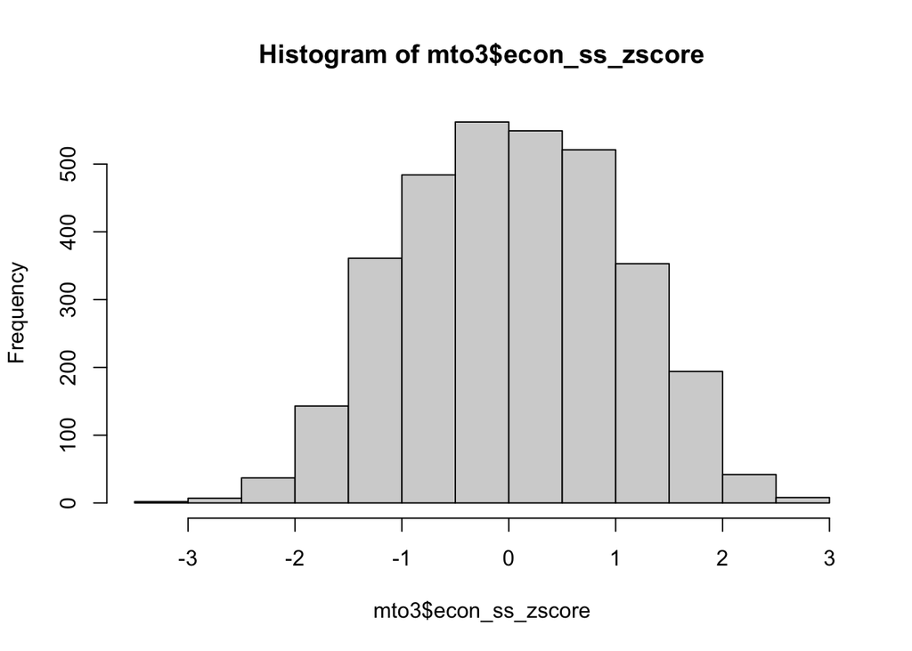

```r
hist(mto3$econ_ss_zscore)
```

The distribution of the economic self-sufficiency variable is bell-shaped, and roughly symmetric with self-sufficiency scores decreasing in frequency as we move away from the mean of zero. The sample mean is .03 with the sample median slightly lower and scores ranging from a minimum of -3.2 to a maximum of 2.9. The middle 50% of economic self-sufficiency values are between -0.73 and +0.78. There are no notable gaps, outliers or spikes in the data.

### Answer 2b

```r
summary(mto3$age)
```

```
##    Min. 1st Qu.  Median    Mean 3rd Qu.    Max.
##   18.00   29.00   41.00   40.61   52.50   64.00
```

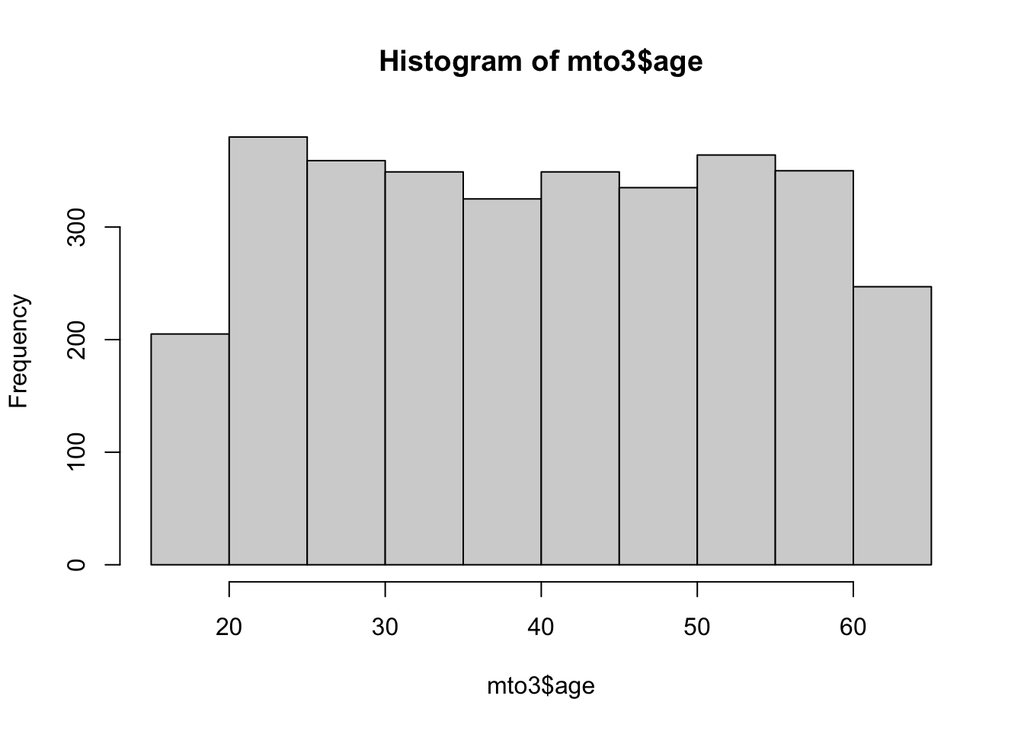

```r
hist(mto3$age)
```

The distribution of age appears to be approximately uniform between the minimum (18) and maximum (64) ages in the data set. The mean and median ages are both about 41 years old, the middle 50% of the ages in the data are between 29 and 52.There are no notable gaps, outliers or spikes in the data.

### Answer 2c

```r
mod1 <- lm(econ_ss_zscore ~ age, data = mto3)
summary(mod1)
```

```
##
## Call:
## lm(formula = econ_ss_zscore ~ age, data = mto3)
##
## Residuals:
##     Min      1Q  Median      3Q     Max
## -3.3157 -0.3553 -0.0025  0.3593  2.1702
##
## Coefficients:
##               Estimate Std. Error t value Pr(>|t|)
## (Intercept) -2.4540300  0.0310497  -79.04   <2e-16 ***
## age          0.0611945  0.0007254   84.36   <2e-16 ***
## ---
## Signif. codes:  0 '***' 0.001 '**' 0.01 '*' 0.05 '.' 0.1 ' ' 1
##
## Residual standard error: 0.5604 on 3261 degrees of freedom
## Multiple R-squared:  0.6858, Adjusted R-squared:  0.6857
## F-statistic:  7117 on 1 and 3261 DF,  p-value: < 2.2e-16
```

### Answer 2d

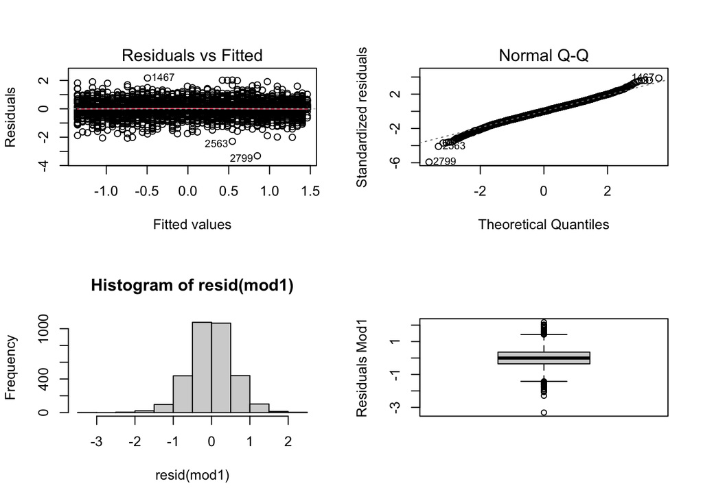

```r
par(mfrow = c(2,2))
plot(mod1, c(1, 2))
hist(resid(mod1))
boxplot(resid(mod1), ylab = "Residuals Mod1")
```

The linearity assumption is not violated because the residual plot appears to have a mean residual of zero across the entire range of fitted values as we look from left to right. The constant variance assumption is also not violated because the variance or spread of the residuals appears to be more or less equal across the range of fitted values as we look from left to right.

We find some evidence for violations of the normality assumption from the QQ plot, because the tails of the distribution of residuals do not match the theoretical quantiles exactly. As the violations are restricted to the tails of the distribution and hence are mild and the data set is large (several thousand observations), it is safe to ignore this violation and proceed assuming that the inferences about the regression results are approximately accurate. In addition, the histogram and boxplot show a mound shaped symmetric distribution. There are outliers but they are on both ends of the distribution.

### Answer 2e

The linearity assumption not being violated indicates that the y-intercept and slope estimates are unbiased and useful for describing the relationship between age and mean economic self-sufficiency. It also indicates that the r-squared estimate is unbiased and meaningful.

The constant variance assumption not being violated indicates that the RMSE estimate is meaningful.

The normality assumptions approximately holding with large data (along with the constant variance assumption) indicates that the standard error estimates for beta-hat and alpha-hat are unbiased, the sampling distributions for beta-hat and alpha-hat are (or are well approximated by) a t-distribution with n – 2 degrees of freedom.

## Question 3 [12 pts]

### Question 3a [5 points]

Interpret the model results as indicated by your answer to Question 2. Interpret each of the following aspects of the model if they are valid to interpret: estimated y-intercept, estimated slope, r-squared value, RMSE, and p-value for the slope.

### Question 3b [2 points]

What do these interpretations tell you about the hypothesis test stated in Question 1?

### Question 3c [3 points]

Under the null hypothesis, describe what the sampling distribution of the estimated slope coefficient for age would be over repeated sampling, if all three assumptions of linear regression held (were not violated) - include information about the shape, mean, and standard error of the sampling distribution.

### Question 3d [2 points]

Make a scatterplot of the age and economic self-sufficiency data and add the estimated regression line to the figure.

## Answer 3

### Answer 3a

```r
summary(mod1)
```

```
##
## Call:
## lm(formula = econ_ss_zscore ~ age, data = mto3)
##
## Residuals:
##     Min      1Q  Median      3Q     Max
## -3.3157 -0.3553 -0.0025  0.3593  2.1702
##
## Coefficients:
##               Estimate Std. Error t value Pr(>|t|)
## (Intercept) -2.4540300  0.0310497  -79.04   <2e-16 ***
## age          0.0611945  0.0007254   84.36   <2e-16 ***
## ---
## Signif. codes:  0 '***' 0.001 '**' 0.01 '*' 0.05 '.' 0.1 ' ' 1
##
## Residual standard error: 0.5604 on 3261 degrees of freedom
## Multiple R-squared:  0.6858, Adjusted R-squared:  0.6857
## F-statistic:  7117 on 1 and 3261 DF,  p-value: < 2.2e-16
```

y-intercept: Heads of household with age 0 are estimated to have an average economic self-sufficiency score of -2.5. As this age is outside of the scope of observed data, this interpretation is not meaningful.

R-squared: 68.6% of the variation in economic self-sufficiency is accounted for by its linear relationship with age.

RMSE: The square root of the average of squared differences between observed and fitted values is 0.56, where the units are the same as the outcome variable - or less technically, the average distance people’s individual economic self-sufficiency is away from the mean economic self-sufficiency for those of their age is 0.56.

slope: The estimated slope coefficient on age is 0.06, indicating that a one-year increase in age is associated with a 0.06 increase in average economic self-sufficiency – or equivalently, a 10-year increase in age is associated with a 0.6 increase in average economic self-sufficiency.

p-value for the slope: The p-value for the slope coefficient is tiny (less than 2e-16), indicating that obtaining a slope coefficient estimate this far (or any farther) from the null of zero was very unlikely to have occurred by chance.

### Answer 3b

We would therefore reject the null hypothesis under any reasonable choice of alpha (0.10, 0.05, 0.01, 0.001) in favor of the alternative and conclude that on average, economic self-sufficiency increases with age.

### Answer 3c

Sampling distribution under the null: a normal distribution, or t-distribution with 3261 df. The mean of the sampling distribution under the null is 0. The estimate of the standard error of the sampling distribution is 0.0007.

### Answer 3d

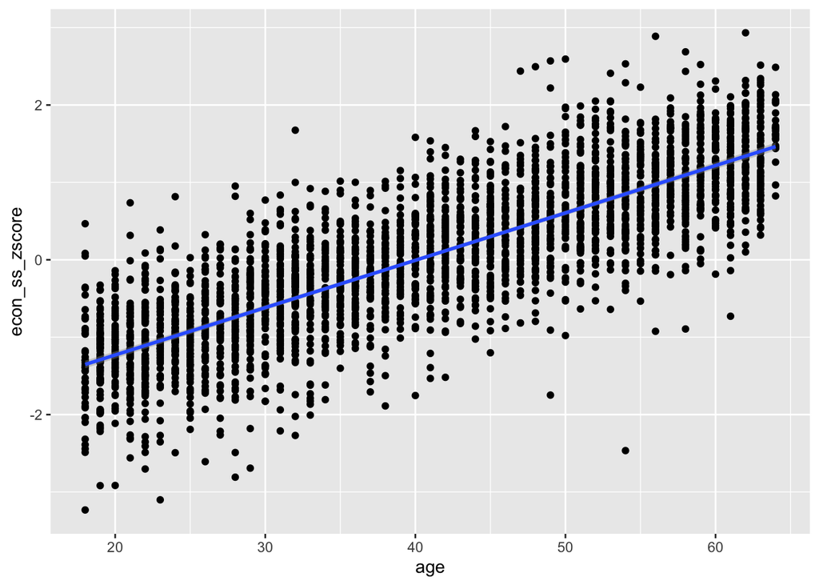

```r
mto3 %>%
   ggplot(aes(y = econ_ss_zscore, x = age)) +
   geom_point() +
   geom_smooth(method = lm, se = TRUE, level = 0.99)
```

## Question 4 [9 pts]

### Question 4a [2 points]

Create a dichotomous `lpv` variable that takes the value 1 for all households with a *low poverty voucher* and takes the value 0 for all other households. The researchers also hypothesize that the *low poverty voucher* will improve economic self-sufficiency (relative to control and Section 8 groups combined - these can be referred to as usual housing support). For this hypothesis, state the specific causal question.

### Question 4b [4 points]

State the potential outcomes for a single household. What linear regression model might be useful to test this hypothesis (include age as a covariate in the model and the dichotomous `lpv` variable)? What is the parameter of interest?

### Question 4c [3 points]

What are the null and alternative hypotheses? Use a two-sided hypothesis test.

## Answer 4

### Answer 4a

```r
mto3$lpv <- mto3$group == "lpv"
```

The causal question is ``what is the effect of receiving the low poverty voucher relative to usual housing support on economic self-sufficiency (holding age constant) for eligible low income families?"

### Answer 4b

Potential outcomes for a single household are what that household’s economic self-sufficiency score would be if they received a low poverty voucher and what that same household’s economic self-sufficiency score would be with usual housing support.

We could test the researcher’s hypothesis using a linear regression model that regresses economic self-sufficiency (the outcome) on a dichotomous variable indicating whether a household received the lpv relative to usual housing support, as well as any number of covariates that may help explain economic self-sufficiency (e.g., age). $E_i = \alpha + \beta_1*Age_i +\beta_2*LPV_i +\epsilon_i$

The parameter of interest here is the true value of the coefficient on lpv ($\beta_2$).

### Answer 4c

The null hypothesis is that the true coefficient on lpv is zero, $\beta_2 = 0$, and the two-sdied alternative hypothesis is that the true coefficient on lpv is not equal to zero, $\beta_2 \neq 0$.

## Question 5 [19 pts]

### Question 5a [4 points]

Run the multiple linear regression you describe in Question 4. Check the three assumptions of linear regression for this model by making and then assessing appropriate residual plots. For each assumption state whether or not it is violated.

### Question 5b [5 points]

Interpret each of the following aspects of the regression model if they are valid to interpret: r-squared value, RMSE, slope coefficient for age. How do the r-squared value and RMSE differ from what they were in the simple linear regression?

### Question 5c [3 points]

Briefly describe what the two regression lines would look like on a graph where the horizontal axis is age and the vertical axis is the economic self-sufficiency measure.

### Question 5d [3 points]

If valid to do so, interpret the p-value that is relevant for the hypothesis test you state in Question 4. If valid, use an alpha level of 0.05 and give the conclusion of this hypothesis test.

### Question 5e [2 points]

Create a 95% confidence interval for the parameter of interest (if valid to do so). Give a statistical interpretation of this confidence interval (if valid).

### Question 5f [2 points]

What do these results tell you about the specific causal question you stated in Question 4? State and interpret the estimated treatment effect.

## Answer 5

### Answer 5a

```r
mod2 <- lm(mto3$econ_ss_zscore ~ mto3$age + factor(mto3$lpv))
mod2
```

```
##
## Call:
## lm(formula = mto3$econ_ss_zscore ~ mto3$age + factor(mto3$lpv))
##
## Coefficients:
##          (Intercept)              mto3$age  factor(mto3$lpv)TRUE
##             -2.52213               0.06115               0.15649
```

```r
summary(mod2)
```

```
##
## Call:
## lm(formula = mto3$econ_ss_zscore ~ mto3$age + factor(mto3$lpv))
##
## Residuals:
##     Min      1Q  Median      3Q     Max
## -3.4019 -0.3515  0.0058  0.3513  2.0831
##
## Coefficients:
##                        Estimate Std. Error t value Pr(>|t|)
## (Intercept)          -2.5221266  0.0319083 -79.043  < 2e-16 ***
## mto3$age              0.0611529  0.0007185  85.117  < 2e-16 ***
## factor(mto3$lpv)TRUE  0.1564944  0.0195483   8.006 1.64e-15 ***
## ---
## Signif. codes:  0 '***' 0.001 '**' 0.01 '*' 0.05 '.' 0.1 ' ' 1
##
## Residual standard error: 0.555 on 3260 degrees of freedom
## Multiple R-squared:  0.6918, Adjusted R-squared:  0.6917
## F-statistic:  3660 on 2 and 3260 DF,  p-value: < 2.2e-16
```

The linearity assumption not being violated indicates that the y-intercept and slope estimates are unbiased and useful for describing the relationship between the low poverty voucher, age, and economic self-sufficiency. It also indicates that the RMSE and r-squared estimates are unbiased although the RMSE may not be meaningful.

The constant variance assumption not being violated indicates that the RMSE estimate is meaningful.

The normality assumptions approximately holding with large data (along with the constant variance holding) indicates that the standard error estimates for beta-hat and alpha-hat are unbiased and the sampling distributions for beta-hat and alpha-hat are (or are well approximated by) a t-distribution with n – 3 degrees of freedom.

### Answer 5b

R-squared: 69% of variation in economic self-sufficiency is accounted for by its linear relationship with age and treatment. This is only very slightly higher than the model with only age as a predictor suggesting that treatment is not a strong predictor of economic self-sufficiency particularly in comparison to how predictive age is.

Slope coefficient on age: The slope coefficient on age is 0.06, indicating that a one-year increase in age is associated with a 0.06 increase in average economic self-sufficiency – or equivalently, a 10-year increase in age is associated with a 0.6 increase in average economic self-sufficiency.

### Answer 5c

A figure showing the estimated multiple linear regression in this question will have two parallel lines, one for those with the low poverty voucher, and one without, which will have the same slope, but will be separated by a shift which corresponds to the coefficient on lpv in the model we ran in this question. The low poverty voucher group line is above the usual housing support line. Both lines are upwardly sloping (and parallel) with increasing age of head of household. This distance between the two up-sloping parallel lines (0.16) is the estimated average treatment effect (controlling for age) with the lvp line above the usual housing support line.

### Answer 5d

p-value for the coefficient on lpv: The p-value for the coefficient on lpv is very small. The p-value indicates the probability that this result, or one any farther from the null, occurred by chance under the null hypothesis that the true coefficient is zero. We would therefore reject the null hypothesis in favor of the alternative at any common significance level in favor of the alternative (0.10, 0.05, 0.01, 0.001). Note that the default in R is to give the p-value for the two-sided hypothesis test.

### Answer 5e

```r
confint(mod2)
```

```
##                            2.5 %      97.5 %
## (Intercept)          -2.58468892 -2.45956425
## mto3$age              0.05974428  0.06256162
## factor(mto3$lpv)TRUE  0.11816628  0.19482248
```

confidence interval on lpv coefficient: The 95% confidence interval for the true population coefficient for lpv is (0.118, 0.195). Over repeated sampling, 95% of samples of this size, with this regression model estimated, would yield confidence intervals constructed in this manner that contain the true population coefficient and 5% would yield confidence intervals that do not contain the true population coefficient.

### Answer 5f

Based on this data, we estimate that the average impact of the low poverty voucher, relative to usual housing support, on economic self-sufficiency not only is not zero but is likely to be between a 0.12 and 0.19 increase in economic self-sufficiency. So while not zero or negative, the positive impact appears to be modest, not more than 0.19 (or less than 0.12).

## Question 6 [12 pts]

### 6a [6 points]

The researchers also hypothesize that the low poverty voucher will have different effects on economic self-sufficiency (relative to usual housing support) for households with older versus younger heads of household.

What linear regression model might be useful to test this hypothesis? What is the parameter of interest? What are the null and (two-sided) alternative hypotheses?

### 6b [6 points]

Run this multiple linear regression. In practice when running multiple linear regression we would check the model assumptions by making and assessing the residual plots, as you did in previous exercises. However, for the purposes of this homework, you can skip making these plots for this subsection - we’ve checked them and found that all 3 assumptions of linear regression hold.

***NOTE: we provide the diagnostic plots for the purposes of the solutions, but students were not expected to make these plots.

Create a scatter plot of age and economic self-sufficiency with the two regression lines added. Color the data points to indicate for each household if they were in the *low poverty voucher group* or group receiving usual housing support. Using an alpha level of 0.10, carry out the hypothesis test you stated in 6a (interpret the p-value and give the conclusion of the hypothesis test) and interpret its implications for the researcher’s hypothesis.

## Answer 6

### Answer 6a

The linear regression model that could be used to test this hypothesis is:

$E_i = \alpha + \beta_1*Age_i +\beta_2*LPV_i +\beta_3*Age_i*LPV_i +\epsilon_i$

From this model, the parameter of interest is $\beta_3$.

The Null Hypothesis is $\beta_3 = 0$ The Alternative Hypothesis is $\beta_3 \neq 0$

### Answer 6b

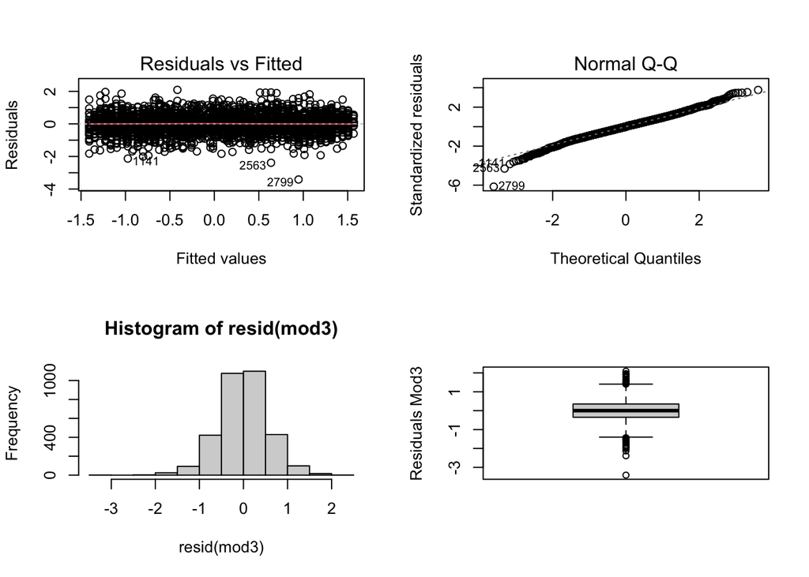

```r
mod3 <- lm(mto3$econ_ss_zscore ~ mto3$age + factor(mto3$lpv) + mto3$age*factor(mto3$lpv))

par(mfrow = c(2,2))
plot(mod3, c(1, 2))
hist(resid(mod3))
boxplot(resid(mod3), ylab = "Residuals Mod3")
```

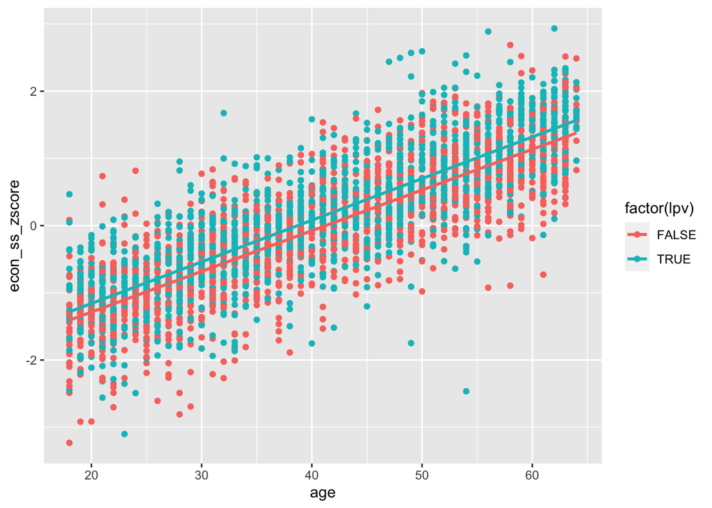

```r
ggplot(data = mto3, aes(x = age, y = econ_ss_zscore, color = factor(lpv))) +
   geom_point() +
   geom_smooth(method = lm, se = FALSE)
```

```r
summary(mod3)
```

```
##
## Call:
## lm(formula = mto3$econ_ss_zscore ~ mto3$age + factor(mto3$lpv) +
##     mto3$age * factor(mto3$lpv))
##
## Residuals:
##     Min      1Q  Median      3Q     Max
## -3.4126 -0.3499  0.0018  0.3528  2.0902
##
## Coefficients:
##                                 Estimate Std. Error t value Pr(>|t|)
## (Intercept)                   -2.4974800  0.0407065 -61.353   <2e-16 ***
## mto3$age                       0.0605448  0.0009514  63.637   <2e-16 ***
## factor(mto3$lpv)TRUE           0.0989838  0.0621341   1.593    0.111
## mto3$age:factor(mto3$lpv)TRUE  0.0014152  0.0014513   0.975    0.330
## ---
## Signif. codes:  0 '***' 0.001 '**' 0.01 '*' 0.05 '.' 0.1 ' ' 1
##
## Residual standard error: 0.555 on 3259 degrees of freedom
## Multiple R-squared:  0.6919, Adjusted R-squared:  0.6917
## F-statistic:  2440 on 3 and 3259 DF,  p-value: < 2.2e-16
```

All three model assumptions hold:

The linearity assumption is not violated because in the residual plot the residuals appear to have a mean of zero across the entire range of fitted values as we look from left to right.

The constant variance assumption is also not violated because the variance or spread of the residuals appears to be more or less equal across the range of fitted values as we look from left to right.

We find some evidence for violations of the normality assumption from the QQ plot, because the tails of the distribution of residuals do not match the theoretical quantiles exactly. However the histrogram shows a mound shaped mostly symmetric distribution ) perhaps some slight low skew. The boxplot shows also suggests symmetry and shows some outliers at both the ends of the distribution. As the violations are restricted to the tails of the distribution and hence are mild and the data set is large (several thousand observations), it is safe to ignore this violation and proceed with analyzing the inferences regarding the regression results.

The estimated coefficient on the interaction term is 0.975 standard errors away from the Null value of zero. Under the null hypothesis obtaining a value this far or any farther from zero just by chance is 0.330. We do not reject the Null with an $\alpha$ level of 0.10. The implications of this result for the researchers hypothesis is that we cannot reject that the low poverty voucher (relative to usual housing support) has the same average impact on economic self-sufficiency for households whose head of household are different ages.